# Ann Arbor R User Meetup

May 7, 2015

## Acknowledgments

Examples and figures used in this presentation come from:

James, G., Witten D., Hastie, T., Tibshirani, R. "An Introduction to Statistical Learning, with applications in R". Springer, 2013.

You can download it here:  
http://www-bcf.usc.edu/~gareth/ISL/ISLR%20First%20Printing.pdf

## Overview of supervised learning

Predictive models that are calibrated on a set of training data and validated on a set of test data

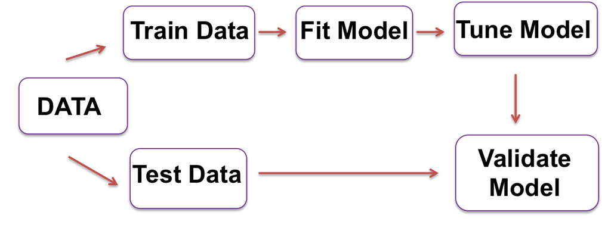

## What are Support Vector Machines?

SVM is typically used as a classification algorithm

- It is an umbrella term for:
  - Maximal margin classifier
  - Support vector classifier
  - Support vector machine
- It is a popular algorithm because:
  - It works well in a variety of settings
  - It sounds cool

## Separating Hyperplanes

- SVM classifies data with a separating hyperplane
- A hyperplane is a flat surface with dimension **p-1**
- If the data are linearly-seperable, there will be an infinite number of separating hyperplanes

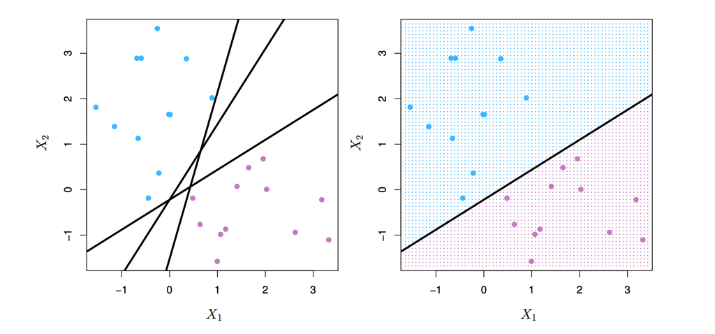

## Maximal Margin Classifier

- The goal of the maximal margin classifier is to find a hyperplane with the widest margin between the two classes
- We hope that a large margin on the training data will translate to a large margin on the test data

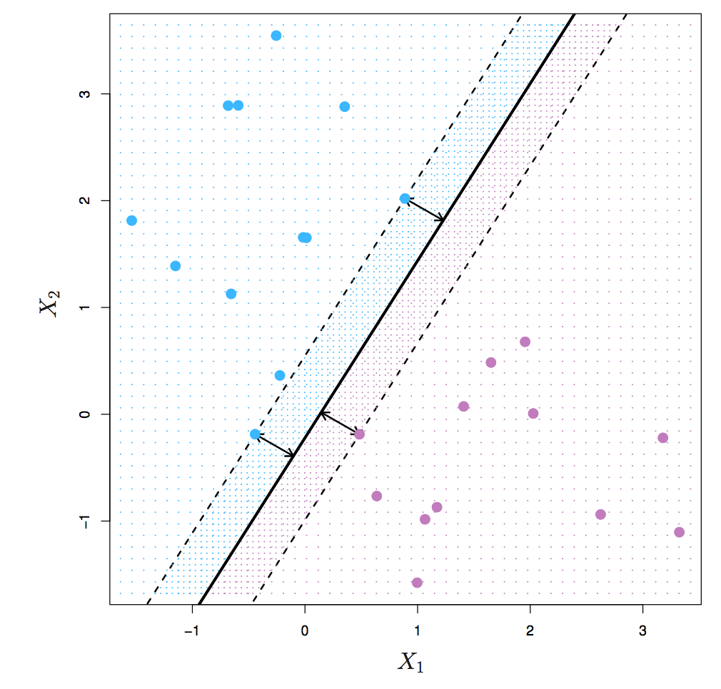

## Support Vectors

- Observations on the edge of the margin are called  
  **support vectors**
- If these points were moved slightly, the maximal margin hyperplane would move as well.

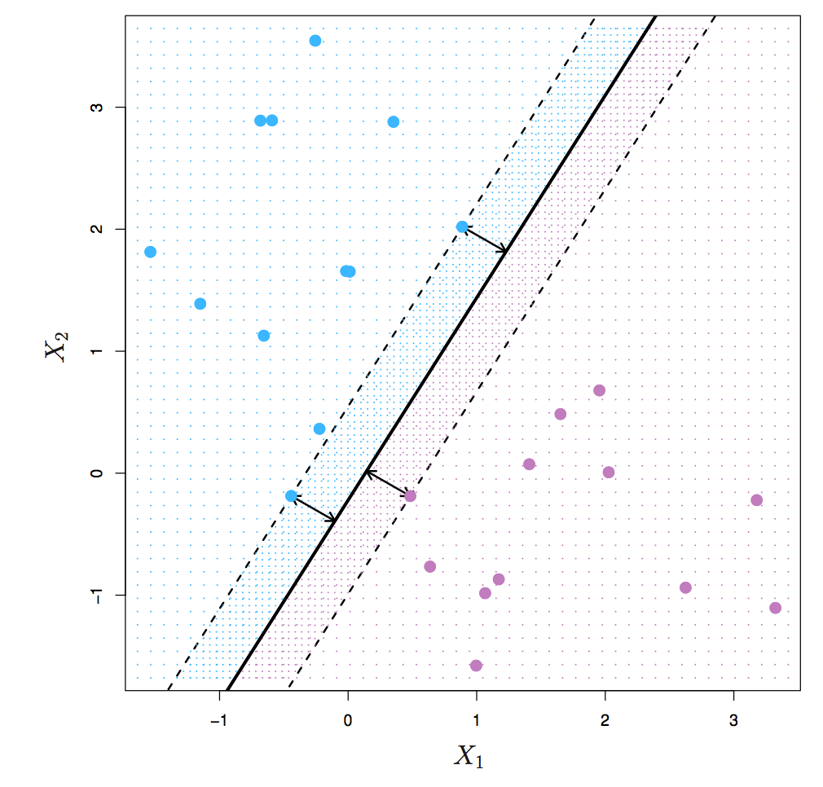

## Maximal Margin is not ideal!

- If a separating hyperplane exists, it will necessarily perfectly classify all training points
  - Classifier will likely **overfit** the training data and  
    perform poorly on a naive set of data
- Also, what if your classes are not linearly separable?

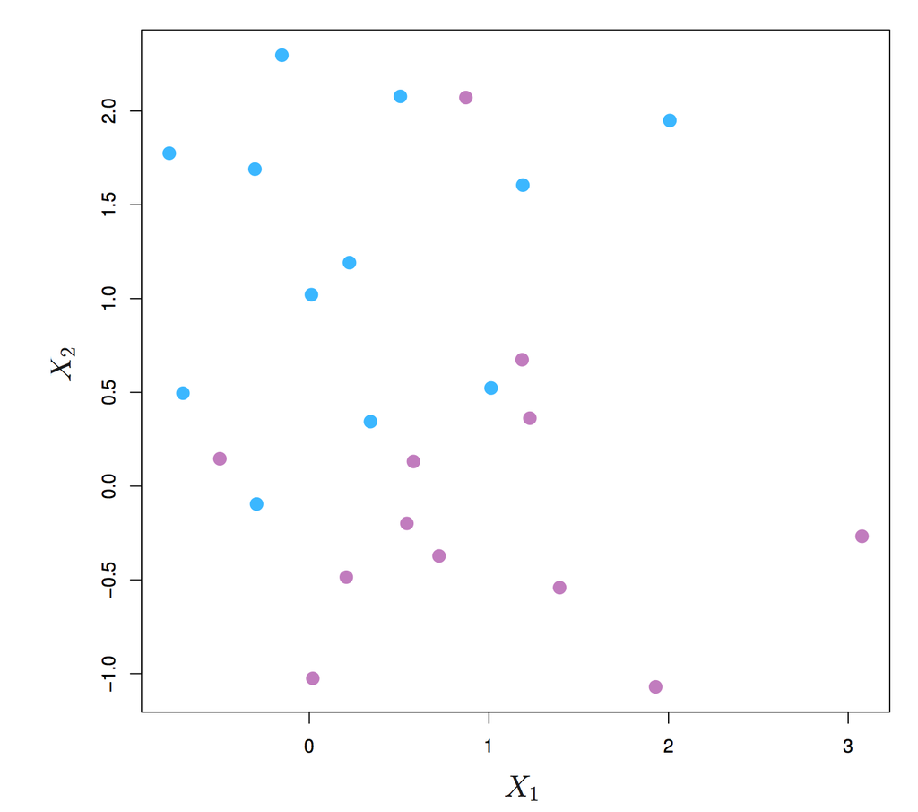

## Solution: use a *soft* margin

Support Vector Classifier

- We allow some points to cross the margin and hyperplane
- Good solution if your classes are *close* to linearly separable
- More robust than the maximal margin classifier because it is **less sensitive** to individual observations
  - model has lower **variance**

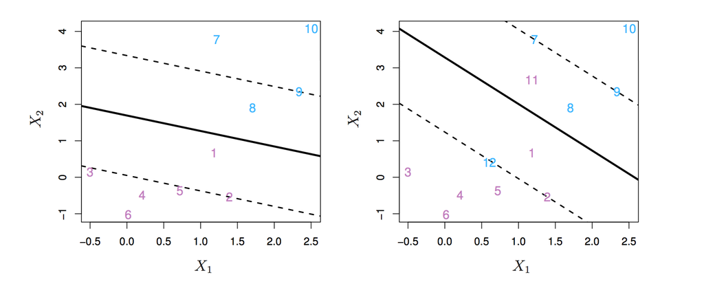

## How to construct a Support Vector Classifier

Introduce a **Cost Function** that tells you how expensive it is for training data points to violate the margin

- **Cost** is chosen through a cross-validation method such as  
  k-folds
- High **Cost** = smaller margin; lower bias, higher variance
- Low **Cost** = wider margin; higher bias, lower variance

## Examples of different **Cost** values

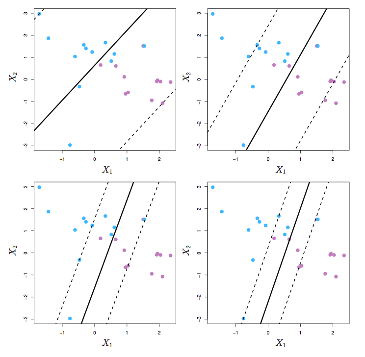

## What if your decision boundary isn't linear at all?

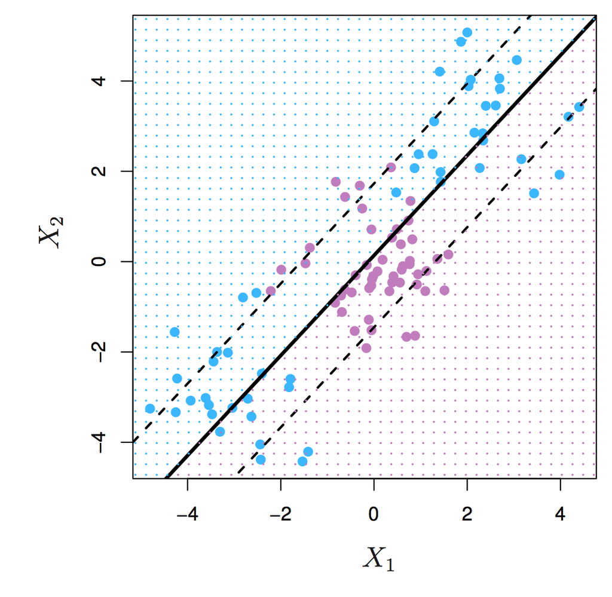

- Use a support vector machine to enlarge the feature space in ways to make the boundary linear

## Support Vector Machine

One solution for enlarging the feature space is to use transformations of the features

For example, rather than fitting a support vector classifier with p features:

X1,X2, . . . Xp

Fit it with 2p features:

X1, (X1)^2, X2, (X2)^2, . . . Xp, (Xp)^2

- In the expanded feature space the decision boundary is linear

## Kernels

- The previous method will quickly generate a very large feature space and may become computationally intractable
- Instead, we can apply a kernel

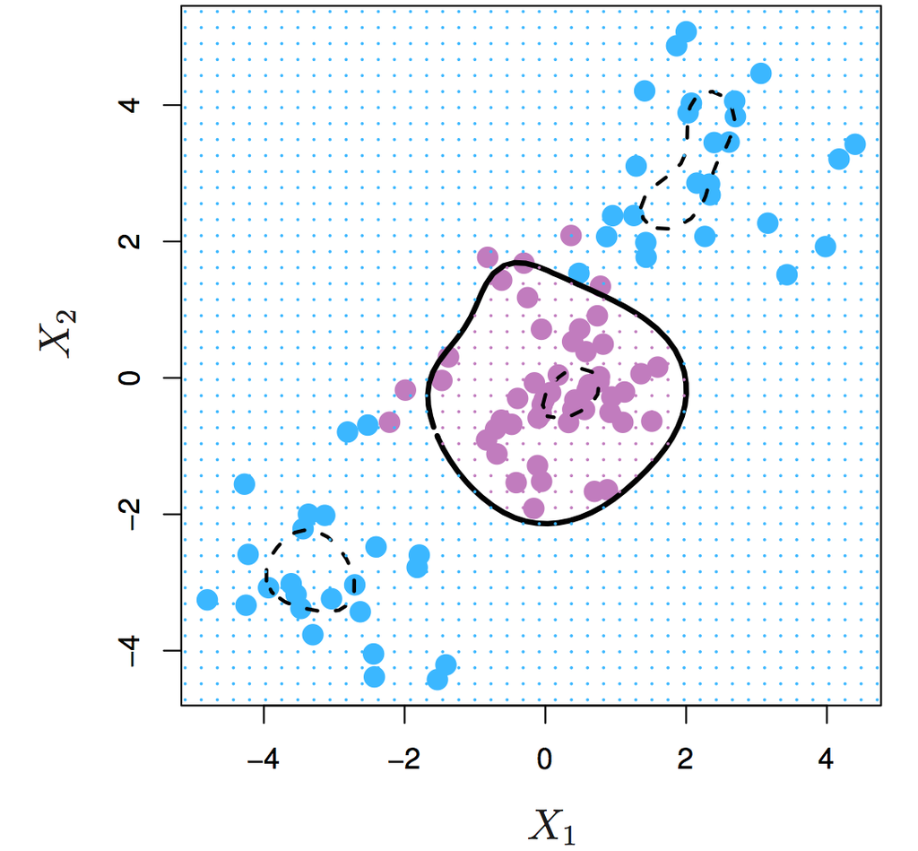

## SVM with more than 2 classes

SVM does not translate elegantly to a multiclass situation

- One vs One
  - Construct classifiers for all possible pairwise combinations of classes
  - Pick the class that was selected the most times
- One vs All
  - Compare one of the K classes to remaining K-1 classes
  - Pick the class that's furthest from the margin
  - The logic here is we have the most confidence that that data point actually belongs to that class

## Example 1:

Support Vector Machine with radial kernel

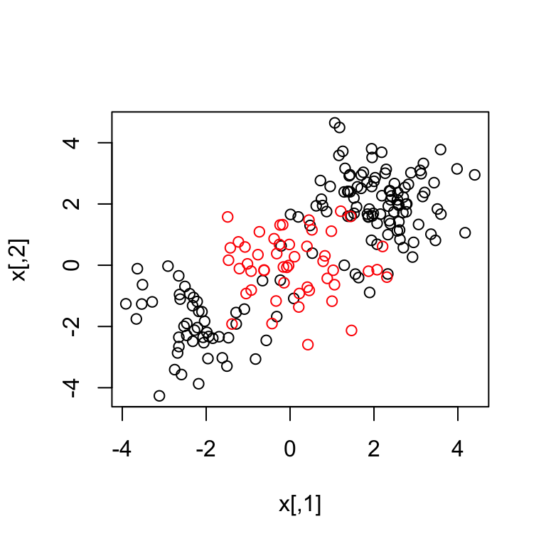

## Train model

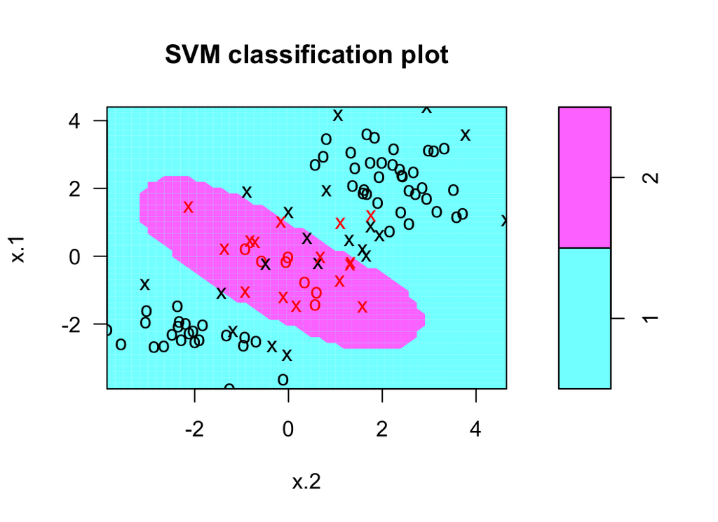

```r
library(e1071)
set.seed(1)
train=sample(200,100)
svmfit=svm(y~., data=radial.data[train,],
           kernel="radial", gamma=1, cost=1)
plot(svmfit, radial.data[train,])
```

```r
summary(svmfit)
```

```
##
## Call:
## svm(formula = y ~ ., data = radial.data[train, ], kernel = "radial",
##     gamma = 1, cost = 1)
##
##
## Parameters:
##    SVM-Type:  C-classification
##  SVM-Kernel:  radial
##        cost:  1
##       gamma:  1
##
## Number of Support Vectors:  35
##
##  ( 20 15 )
##
##
## Number of Classes:  2
##
## Levels:
##  1 2
```

## Tune model

```r
set.seed(1)
tune.out=tune(svm,y~., data=radial.data[train,], kernel="radial",
              ranges=list(cost=c(.1,1,10,100,1000),
              gamma=c(.5,1,2,3,4)))
```

```r
summary(tune.out)
```

```
##
## Parameter tuning of 'svm':
##
## - sampling method: 10-fold cross validation
##
## - best parameters:
##  cost gamma
##   100   0.5
##
## - best performance: 0.1
##
## - Detailed performance results:
##     cost gamma error dispersion
## 1  1e-01   0.5  0.22 0.13984118
## 2  1e+00   0.5  0.11 0.12866839
## 3  1e+01   0.5  0.11 0.12866839
## 4  1e+02   0.5  0.10 0.12472191
## 5  1e+03   0.5  0.13 0.14181365
## 6  1e-01   1.0  0.22 0.13984118
## 7  1e+00   1.0  0.10 0.10540926
## 8  1e+01   1.0  0.11 0.12866839
## 9  1e+02   1.0  0.12 0.13165612
## 10 1e+03   1.0  0.16 0.10749677
## 11 1e-01   2.0  0.22 0.13984118
## 12 1e+00   2.0  0.10 0.12472191
## 13 1e+01   2.0  0.12 0.13165612
## 14 1e+02   2.0  0.17 0.10593499
## 15 1e+03   2.0  0.13 0.09486833
## 16 1e-01   3.0  0.22 0.13984118
## 17 1e+00   3.0  0.12 0.12292726
## 18 1e+01   3.0  0.13 0.10593499
## 19 1e+02   3.0  0.13 0.08232726
## 20 1e+03   3.0  0.18 0.11352924
## 21 1e-01   4.0  0.22 0.13984118
## 22 1e+00   4.0  0.13 0.12516656
## 23 1e+01   4.0  0.14 0.10749677
## 24 1e+02   4.0  0.14 0.08432740
## 25 1e+03   4.0  0.18 0.11352924
```

## Test model

```r
test <- -train
svm.pred <- predict(tune.out$best.model,
            newx=radial.data[test,])
confusion.table <- table(true <- radial.data[test,"y"],svm.pred)
confusion.table
```

```
##    svm.pred
##      1  2
##   1 62 10
##   2 19  9
```

```r
sum(diag(confusion.table))/sum(confusion.table)
```

```
## [1] 0.71
```

## Example 2:

Support Vector Classifier with gene expression data

- Khan dataset:
  - 83 observations of 2308 genes
  - Goal is to classify tissue samples into 4 tumor types based on gene expression

## Train model

```r
library(ISLR)
khan.train <- data.frame(x=Khan$xtrain,y=as.factor(Khan$ytrain))
# khan.tune <- tune(svm,y~., data=khan.train,kernel="linear",
                  # ranges=list(cost=c(.1,1,10,100,1000)))
khan.svm <- svm(y~., data=khan.train, kernel = "linear", cost=10)
```

- gamma not required for linear kernel
  - uses 1/data dimension
- this function uses the one vs one approach for multiclass svm

```r
summary(khan.svm)
```

```
##
## Call:
## svm(formula = y ~ ., data = khan.train, kernel = "linear", cost = 10)
##
##
## Parameters:
##    SVM-Type:  C-classification
##  SVM-Kernel:  linear
##        cost:  10
##       gamma:  0.0004332756
##
## Number of Support Vectors:  58
##
##  ( 20 20 11 7 )
##
##
## Number of Classes:  4
##
## Levels:
##  1 2 3 4
```

## Training data results

```r
table(khan.svm$fitted, khan.train$y)
```

```
##
##      1  2  3  4
##   1  8  0  0  0
##   2  0 23  0  0
##   3  0  0 12  0
##   4  0  0  0 20
```

- model perfectly classifies all the training data

## Test model

```r
khan.test <- data.frame(x=Khan$xtest, y = as.factor(Khan$ytest))
pred <- predict(khan.svm, newdata=khan.test)
khan.table <- table(pred,khan.test$y)
khan.table
```

```
##
## pred 1 2 3 4
##    1 3 0 0 0
##    2 0 6 2 0
##    3 0 0 4 0
##    4 0 0 0 5
```

```r
sum(diag(khan.table)/sum(khan.table))
```

```
## [1] 0.9
```

- model performs very well on test data too!

## SVM vs Logistic Regression

- SVM does better when classes are (nearly) separable
- When classes are not, LR (ridge penalty) and SVM are very similar
- You can estimate probabilities with Logistic Regression
- You can use kernels with LR too, but it is more costly computationally

## Resources

Parallel predictions with SVM in R http://www.vikparuchuri.com/blog/parallel-r-model-prediction-building/